# Vignette for selbal package

J. Rivera-Pinto, University of Vic and IrsiCaixa

updated (July 2019) by M.Calle (University of Vic), A. Susin (UPC-BarcelonaTech)

In this vignette we illustrate the use of **selbal** , an R package for selection of balances in microbiome compositional data. As described in Rivera-Pinto et al. 2018 *Balances: a new perspective for microbiome analysis* [10.1128/mSystems.00053-18](https://doi.org/10.1101/219386), **selbal** implements a forward-selection method for the identification of two groups of taxa whose relative abundance, or balance, is associated with the response variable of interest.

# Installing and loading **selbal**

**selbal** package is available on GitHub and can be installed on your computer through the following instructions:

```r
# Load "devtools" library (install it if needed)
  library(devtools)

# Install "selbal""
  install_github(repo = "UVic-omics/selbal")

   For windows users:
   install_url(url="https://github.com/UVic-omics/selbal/archive/master.zip",
                INSTALL_opt= "--no-multiarch")


# Load library
  library(selbal)
```

Once the package is installed, the user can access to all the functions and data sets included in **selbal** .

# Data sets

The package includes three datasets: `HIV`, `sCD14` and `Crohn`. The first two correspond to an HIV study (Noguera-Julian et al. 2016 http://dx.doi.org/10.1016/j.ebiom.2016.01.032). The third dataset corresponds to a Crohn’s disease study (Gevers et al. 2014 http://dx.doi.org/10.1016/j.chom.2014.02.005).

These are their main characteristics:

- `HIV` is a `data.frame` with 155 rows (samples) and 62 columns (variables). The first sixty variables provide the number of counts for microbial taxa at genus taxonomy rank. The last two are:
  - `MSM`: an HIV risk factor, *Men who has sex with men* (*MSM*) or not (*nonMSM*).
  - `HIV_Status`: a factor indicating if the individual is HIV1 positive (*Pos*) or not (*Neg*).
- `sCD14` is a `data.frame` with 151 rows (a subset of individuals from `HIV`) and 61 columns. The first sixty columns again correspond to microbiome information while the last one is a numeric value for the amount of the inflammation marker `sCD14`.
- `Crohn` is a `data.frame` with 975 rows (samples) and 49 columns (variables). 662 samples are cases diagnosed with Crohn’s disease and 313 are controls. The first forty-eight columns conform the microbiome information at genus level and the last one is disease status: Crohn’s disease (CD) or control (no).

Calling by their name, the user can get acces to each data set.

## `selbal.cv` function

`selbal.cv()` is the function of **selbal** package that is intended to answer the following questions:

- **Which is the optimal number of variables to include in the balance?**
- **Which are the taxa whose balance is more associated to the response variable?**
- **Is the proposed balance robust?**

To run the function we need to specify two input objects:

- `x` is a matrix with the microbiome information. It represents the number of counts or reads for each sample (*row*) and each taxon (*column*).
- `y` is a vector with the response variable. It should be specified as a `factor` if the response variable is dichotomous and `numeric` if it is continuous.

The original code has been extended with two additional features: the user can choose the number of variables to be selected `(user_numVar)` and, in addition to the AUC, the optimization criteria for a binary response can be the proportion of explained deviance.

Additional parameters of `selbal.cv` function are:

- `n.fold` : a numeric value indicating the number of folds in the cross - validation procedure. When the response variable is dichotomous the cross-validation is performed so that the total proportion of cases and controls is preserved in each fold. Default `n.fold = 5`.
- `n.iter`: a numeric value indicating the number of iterations to implement; that is, the number of times that the cross - validation process is repeated. Default `n.iter = 10`.
- `logit.acc`: for dichotomous responses, the method to compute the association parameter. Default it is the AUC- ROC value (`logit.acc = "auc"`), but other alternatives are also included: `logit.acc = "Dev"` for the proportion of explained deviance ,`logit.acc = "rsq"` or `logit.acc = "tjur"` (see the paper to obtain more information);.
- `maxV`: the maximum number of variables to be included in a balance. Default `maxV = 20`.
- `zero.rep` : it defines the method used for the zero-replacement. If it is `"bayes"` the Bayesian - Multiplicative treatment implemented in `{zCompositions}` is applied. If it is `"one"`, a pseudocount of 1 is added to the whole matrix.
- `opt.cri` parameter for selecting the method to determine the optimal number of variables. `"max"` to define this number as the number of variables which maximizes the association value or `"1se"` to take also the standard error into account. Default `opt.cri = "1se"`.
- `user_numVar`: the number of variables to be included in a balance despite of the computed optimal value. Default `user_numVar = NULL`.

There are also additional sequndary parameters. To get more information run `?selbal.cv`.

## HIV INFECTION AND MICROBIOME

In this case we explore a possible association between HIV infection and microbiome composition. More precisely, we apply `selbal.cv()` with the goal of identifying a microbiome balance between two groups of taxa associated to the HIV Status. According to Noguera-Julian et al. (2016) *MSM* factor is a possible confounder in HIV microbiome studies. Thus, we will add *MSM* in the analysis through the `covar` parameter.

```r
################################################################################
# Microbiomne and HIV: using a dichotomous response
################################################################################

# Define x, y and z
  x <- HIV[,1:60]
  y <- HIV[,62]
  z <- data.frame(MSM = HIV[,61])

# Run selbal.cv function (with the default values for zero.rep and opt.cri)
  CV.BAL.dic <- selbal.cv(x = x, y = y, n.fold = 5, n.iter = 10,
                          covar = z, logit.acc = "AUC")
```

```
##
##
## ###############################################################
##  STARTING selbal.cv FUNCTION
## ###############################################################
##
## #-------------------------------------------------------------#
## # ZERO REPLACEMENT . . .
##
##
## , . . . FINISHED.
## #-------------------------------------------------------------#
##
## #-------------------------------------------------------------#
## # Starting the cross - validation procedure . . .
##  . . . finished.
## #-------------------------------------------------------------#
## ###############################################################
##
##  The optimal number of variables is: 2
##
##
##
## ###############################################################
##  . . . FINISHED.
## ###############################################################
```

- **$accuracy.nvar**: the first element of the list is an image representing the distribution of the accuracy measure as a function of the number of variables included in the balance. This values are from 2 to `maxV` where the red dot represents mean accuracy and the branches the standard errors.

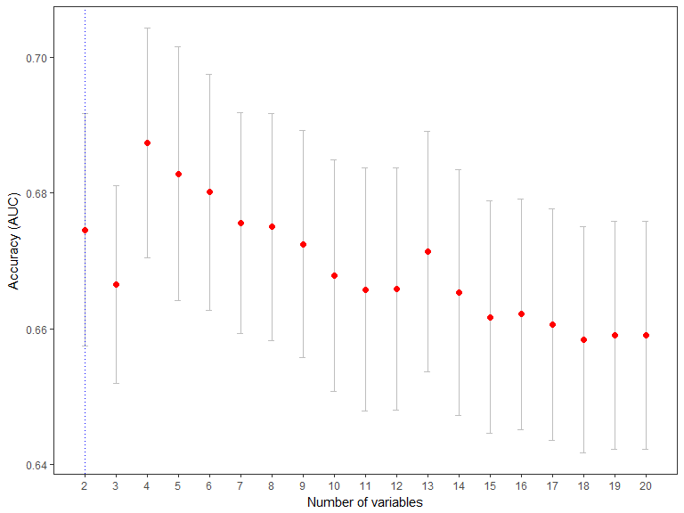

```r
CV.BAL.dic$accuracy.nvar
```

- **$var.barplot**: the second object in the list is a barplot representing the frequency of the variables selected in some step of the CV process (considering only the balances with at most the optimal number of variables defined in the previous step).

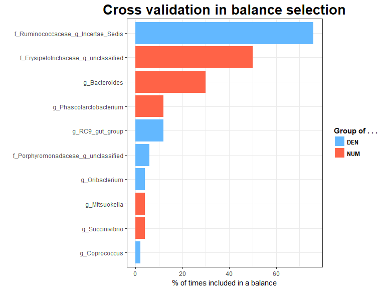

```r
CV.BAL.dic$var.barplot
```

- **$global.plot**: the third element includes a graphical representation of the *Global balance*; the balance obtained with the whole dataset.

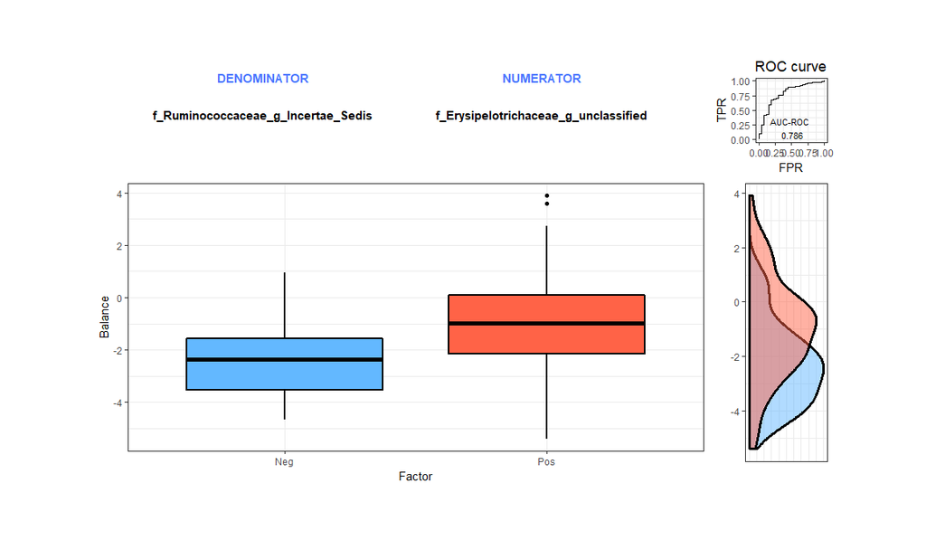

```r
grid.draw(CV.BAL.dic$global.plot)
```

The balance identified as the most associated with HIV-status is given by $X_+$, a taxon of the family *Erysipelotrichaceae* and unknown genus and $X_-$,a taxon of the family *Ruminococcaceae* and unknown genus (top-left of the figure). Higher balance scores are associated to HIV-positive samples, that is, larger relative abundances of *Erysipelotrichaceae* with respect to *Ruminococcaceae* (botton-left of the figure). The score associated to HIV-negative samples is lower compared to HIV-positive individuals, whose balance is more heterogeneous. The apparent discrimination accuracy of this balance (AUC of 0.786, top-right of the figure) is moderate and it is reduced when it is estimated in the CV-process (cv-AUC=0.674). See the fifth element of the output for more details.

- **$cv.tab**: the fourth element of the list is a table with the summary of the CV-procedure. Rows represent the variables included either in the *Global balance* (second column) or the three most frequent balances in the CV process (last three columns). The first column provides the percentage of times each variable has appeared in CV and, the last row points the proportion of times the most repeated balances have appeared.

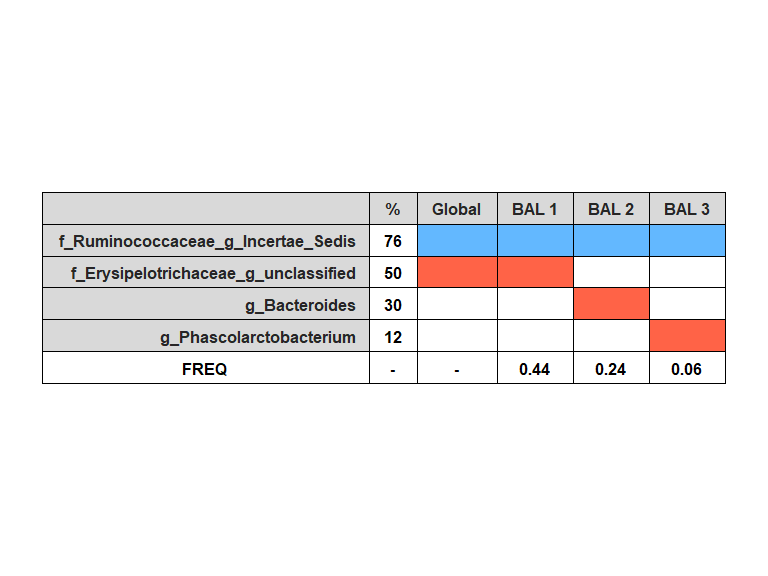

```r
plot.tab(CV.BAL.dic$cv.tab)
```

The *Global balance* is the one most frequently selected in the CV (44%), so it seems to be a robust selection for this dataset. The three most repeated balances include *f_Ruminococcaceae_g_Incertae_Sedis* (the most frequent one) as the variable in the denominator.

- **$cv.accuracy**: The fifth element in the output list is a vector with the test prediction or classification accuracy (AUC in this case) for each cv iteration (length equal to `n.fold*n.iter`).

```r
CV.BAL.dic$cv.accuracy; summary(CV.BAL.dic$cv.accuracy)
```

```
##  [1] 0.7538462 0.8538462 0.8933333 0.6692308 0.4933333 0.8461538 0.7384615
##  [8] 0.5333333 0.7769231 0.7133333 0.5307692 0.9000000 0.5400000 0.6153846
## [15] 0.5333333 0.4461538 0.6692308 0.6400000 0.7230769 0.7600000 0.6000000
## [22] 0.7923077 0.4866667 0.7153846 0.6133333 0.6615385 0.5076923 0.8133333
## [29] 0.8153846 0.8133333 0.6692308 0.6461538 0.5733333 0.5692308 0.6866667
## [36] 0.6230769 0.4538462 0.7033333 0.7307692 0.7133333 0.6615385 0.5230769
## [43] 0.5733333 0.8384615 0.8200000 0.8846154 0.5846154 0.6800000 0.6846154
## [50] 0.6600000
```

```
##    Min. 1st Qu.  Median    Mean 3rd Qu.    Max.
##  0.4462  0.5762  0.6692  0.6746  0.7585  0.9000
```

The mean of these values provides the cross-validation accuracy. In this case, the cross-validation AUC is 0.674, which, as expected, is lower than the appparent AUC value measured on the whole dataset (0.786).

- **$global.balance**: the sixth element of the output is a `data.frame` with the variables included in the *Global Balance*. The first column, `Taxa`, provides the names of the selected taxa while variable `Group` specifies wether the taxon is included in the numerator (NUM) or the denominator (DEN) of the balance.

This table is useful in order to compute the balance score for another different dataset through `bal.value` function. For example, given this table (`tab`) and a matrix corresponding of microbiome information for other samples (`mat`, log-transformed count matrix including at least all the variables presented in `tab`), we can run `bal.value(bal.tab = tab, x = mat)` and we will obtain for each sample a value corresponding to the balance defined in `tab`.

```r
CV.BAL.dic$global.balance
```

```
##                                   Taxa Group
## 1 f_Erysipelotrichaceae_g_unclassified   NUM
## 2   f_Ruminococcaceae_g_Incertae_Sedis   DEN
```

- **$glm**: the seventh element of the list is the result of a regression model. Balance selection is implemented through a regression model where the balance itself and additional covariates are the explanatory variables, and the variable of interest the response. The user has access to the regression model in order to obtain and analyze any of its characteristics.

```r
CV.BAL.dic$glm
```

```
##
## Call:  glm(formula = numy ~ ., family = f.class, data = U)
##
## Coefficients:
## (Intercept)       MSMMSM           V1
##      3.6453      -1.6150       0.5279
##
## Degrees of Freedom: 154 Total (i.e. Null);  152 Residual
## Null Deviance:       143.4
## Residual Deviance: 120.7     AIC: 126.7
```

- **$opt.nvar**: the last element represents the optinal number of variables considered in the balance as the optimal.

```r
CV.BAL.dic$opt.nvar
```

```
## [1] 2
```

## HIV INFECTION AS AN INFLAMMATORY DISEASE

In this second example we deal with a continuous response. Previous studies have proved association between inflammatory diseases and the gut microbiome composition; so, it is expected such a relationship between the gut microbiome and an inflammatory disease like the HIV infection. We will explore the association between the gut microbiome and the inflammation parameter *sCD14*.

For this second example, the input is going to be defined as:

- `x`: the matrix with microbiome information, that is, the first sixty columns of `sCD14`.
- `y`: the response variable, in this case the sCD14 value.

We are going to use the default values for the rest of the parameters:

```r
# Define x, y and z
  x2 <- sCD14[,1:60]
  y2 <- sCD14[,61]

# Run selbal.cv function
  BAL.sCD14 <- selbal.cv(x = x2, y = y2, n.fold = 5, n.iter = 10,
                          covar = NULL)
```

```
##
##
## ###############################################################
##  STARTING selbal.cv FUNCTION
## ###############################################################
##
## #-------------------------------------------------------------#
## # ZERO REPLACEMENT . . .
##
##
## , . . . FINISHED.
## #-------------------------------------------------------------#
##
## #-------------------------------------------------------------#
## # Starting the cross - validation procedure . . .
##  . . . finished.
## #-------------------------------------------------------------#
## ###############################################################
##
##  The optimal number of variables is: 4
##
##
##
## ###############################################################
##  . . . FINISHED.
## ###############################################################
```

With the same format as the results of the previous example, now for sCD14 we have that:

- **$accuracy.nvar**: even though the minimum mean MSE is obtained for eight variables, the lowest value under its mean plus the SE is four; so four is the optimal number of variables for this dataset.

```r
BAL.sCD14$accruacy.nvar
```

[output not shown]

- **$var.barplot**: *f_Lachinospiraceae_g_unclassified* is the genus appearing most times in the cross - validation procedure. There are also three additional genera with a presence above fifty percent.

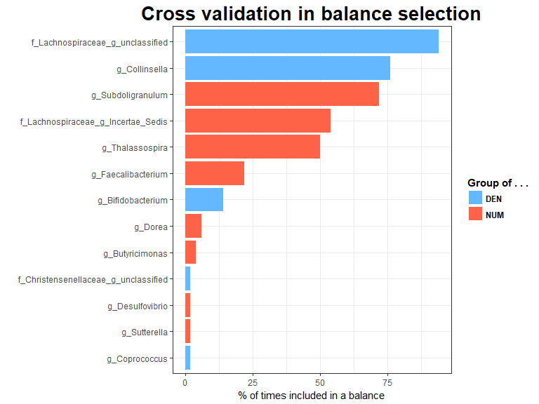

```r
BAL.sCD14$var.barplot
```

- **$global.plot**: the four genera defining the balance are divided into:

$X_+$ = { g_Subdoligranulum, f_Lachnospiraceae_g_Incertae_Sedis}

$X_-$ = { f_Lachnospiraceae_g_unclassified, g_Collinsella}

It is important to highlight that the four variables defining the balance are the most presented ones in the CV (see the previous Figure). Additionally, higher scores for this balance are linked with higher values of sCD14. An R-squared value of 0.281 is obtained for the regression model.

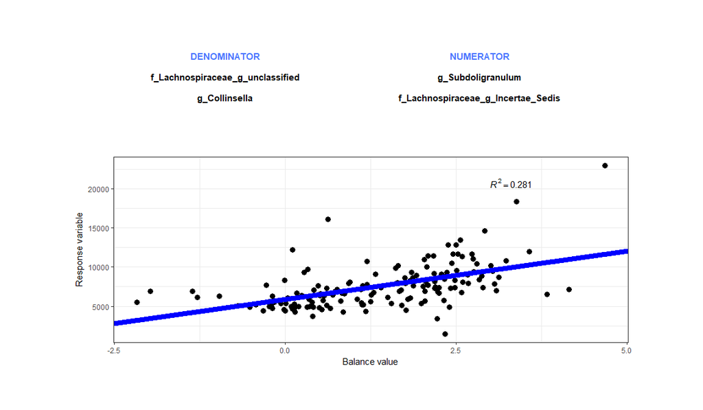

```r
grid.draw(BAL.sCD14$global.plot)
```

- **$cv.tab**: the table indicates that the *Global Balance* appears a 34% of times in the CV-procedure being the most presented one. The second and the third balances are also defined by three out of four of the variables included in the *Global Balance*, which reveals robustness for the proposal.

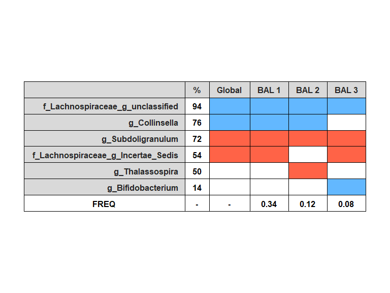

```r
plot.tab(BAL.sCD14$cv.tab)
```

- **$cv.accuracy**: the MSE values for cross - validation procedure are highly variable.

```r
BAL.sCD14$cv.accuracy; summary(BAL.sCD14$cv.accuracy)
```

```
##  [1]  5542911  7128784  5192990 15102251  3728448 11438021  6895642
##  [8]  8262932  5436787  6559485  8964076  4295272  9505753  5550200
## [15]  6214607  7774599 16584320  7947165  7450594  5423896  9308319
## [22] 12795489  5134485  6233639  3881001 17033818  3542431  7900878
## [29]  2805909  4702468  6710420  6368869  5373791  6409906 18025696
## [36]  7008211 14249810  6929410  7013254  4900098  5240813  9019034
## [43] 11979266  2931361  6834546  2643353  9102166 11034806  8668139
## [50]  6913595
```

```
##     Min.  1st Qu.   Median     Mean  3rd Qu.     Max.
##  2643353  5386318  6904618  7713874  9005294 18025696
```

- **$global.balance**: the sixth element of the output is the `data.frame` with the four variables selected in the balance.

```r
BAL.sCD14$global.balance
```

```
##                                 Taxa Group
## 1                  g_Subdoligranulum   NUM
## 2   f_Lachnospiraceae_g_unclassified   DEN
## 3                      g_Collinsella   DEN
## 4 f_Lachnospiraceae_g_Incertae_Sedis   NUM
```

- **$glm**: it shows the result of the regression model defined for the balance selection.

```r
BAL.sCD14$glm
```

```
##
## Call:  glm(formula = numy ~ ., family = f.class, data = U)
##
## Coefficients:
## (Intercept)           V1
##        5857         1229
##
## Degrees of Freedom: 150 Total (i.e. Null);  149 Residual
## Null Deviance:       1.221e+09
## Residual Deviance: 877900000     AIC: 2786
```

- **$opt.nvar**: the last element indicates the optimal number of variables in the balance: four in this case.

```r
BAL.sCD14$opt.nvar
```

```
## [1] 4
```

## Crohn’s disease

The third example is implemented for a Crohn’s disease microbiome data set. It contains almost thousand patients and will allow to evaluate the robustness of the cv process with quite large folds. The aim of this analysis is to find two groups of taxa whose abundance balance is associated to disease status.

So, the fucntion will be run with the following objects as input:

- `x`: the matrix with microbiome information, that is, the first 48 columns of `Crohn` table.
- `y`: the response variable is a case-control indicator.

To run `selbal.cv` function for this example:

```r
  # Load data sets
    x3 <- Crohn[,1:48]
    y3 <- Crohn[,49]

  # Run selbal.cv function
    BAL.Crohn <- selbal.cv(x = x3, y = y3, n.fold = 5, n.iter = 10,
                           covar = NULL, logit.acc = "AUC")
```

```
##
##
## ###############################################################
##  STARTING selbal.cv FUNCTION
## ###############################################################
##
## #-------------------------------------------------------------#
## # ZERO REPLACEMENT . . .
##
##
## , . . . FINISHED.
## #-------------------------------------------------------------#
##
## #-------------------------------------------------------------#
## # Starting the cross - validation procedure . . .
##  . . . finished.
## #-------------------------------------------------------------#
## ###############################################################
##
##  The optimal number of variables is: 12
##
##
##
## ###############################################################
##  . . . FINISHED.
## ###############################################################
```

The results for this data set reveal:

- **$accuracy.nvar**: the number of taxa with the minimum mean MSE value is fourteen. Nevertheless, under its MSE + SE value, twelve is the number of taxa presenting the least MSE, so the considered balance will have twelve microbial taxa.

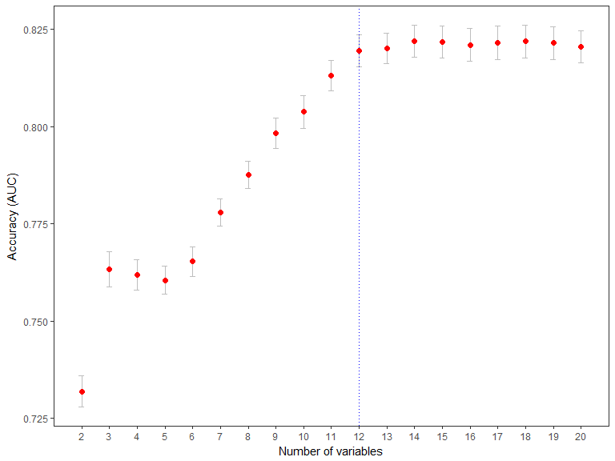

```r
BAL.Crohn$accuracy.nvar
```

- **$var.barplot**: the barplot of the most selected taxa in the cross - validation shows a core of twelve genera appearing at least in 70% of the cv balances. As it is going to be shown later, they are the taxa defining the *Global Balance*.

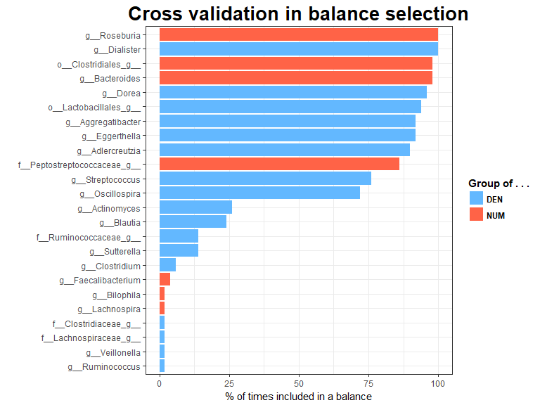

```r
BAL.Crohn$var.barplot
```

- **$global.plot**: the *Global Balance* plot shows the twelve taxa whose balance most discriminates between cases and controls. Both, the boxplot and the density curve reveal that cases with Crohn’s disease have lower balance scores than controls, meaning lower relative abundances of those taxa in the numerator with respect to those in the denominator. The discrimination value (AUC-ROC = 0.838) is very good as well as the cross - validation accuracy (cv-AUC=0.819).

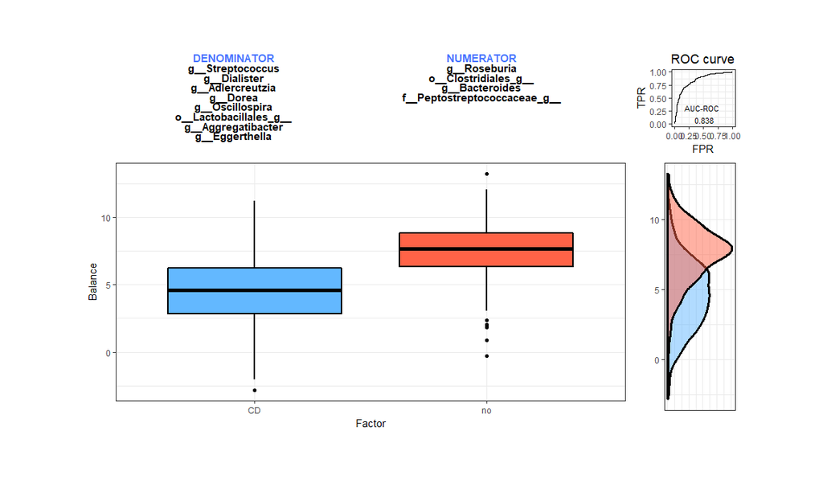

```r
grid.draw(BAL.Crohn$global.plot)
```

- **$cv.tab**: the most repeated balance in the cross - validation is the *Global Balance*. This fact together with the core of taxa appearing in the three most repeated balances, reveal a robust structure linked with Crohn’s disease in this data set.

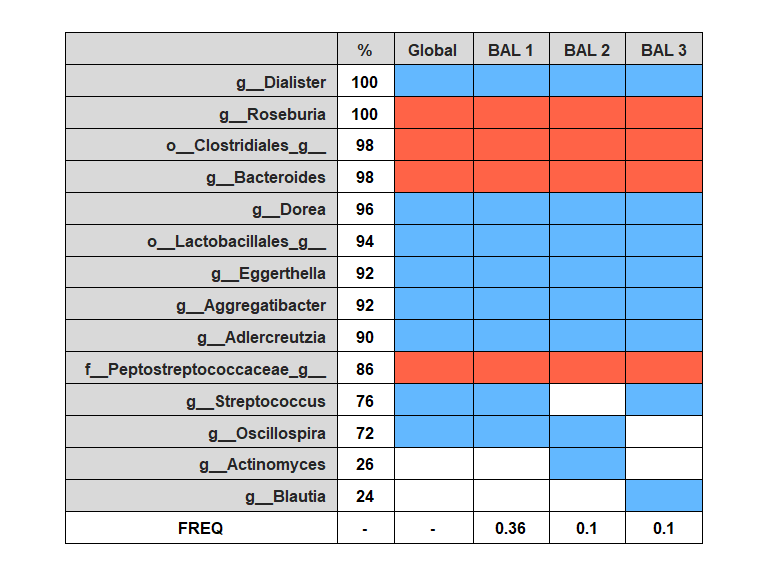

```r
plot.tab(BAL.Crohn$cv.tab)
```

- **$cv.accuracy**: the mean AUC for the test datasets is very close to the AUC for the global balance; so , this is another fact that emphasized the robustness of the proposed balance.

```r
BAL.Crohn$cv.accuracy ; summary(BAL.Crohn$cv.accuracy)
```

```
##  [1] 0.8041475 0.8386243 0.8482443 0.8035113 0.8519282 0.8150618 0.7768158
##  [8] 0.8489658 0.8241943 0.8047538 0.7904439 0.8484848 0.8284031 0.7782588
## [15] 0.8550813 0.8792142 0.8304473 0.8430736 0.7944925 0.7915353 0.8474412
## [22] 0.8328523 0.8442761 0.7941318 0.8110599 0.7672811 0.8164983 0.8498076
## [29] 0.7389370 0.8399224 0.8634489 0.8180616 0.8107263 0.7989418 0.8220956
## [36] 0.8092408 0.8342953 0.8383838 0.8387446 0.8019646 0.7729808 0.7651515
## [43] 0.8309283 0.8632756 0.7932331 0.8062091 0.8203463 0.8216691 0.8465608
## [50] 0.8260975
```

```
##    Min. 1st Qu.  Median    Mean 3rd Qu.    Max.
##  0.7389  0.8024  0.8219  0.8196  0.8423  0.8792
```

- **$global.balance**: the sixth element of the output is a data.frame with the selected taxa.

```r
BAL.Crohn$global.balance
```

```
##                            Taxa Group
## 1                  g__Roseburia   NUM
## 2              g__Streptococcus   DEN
## 3                  g__Dialister   DEN
## 4              g__Adlercreutzia   DEN
## 5                      g__Dorea   DEN
## 6          o__Clostridiales_g__   NUM
## 7               g__Oscillospira   DEN
## 8        o__Lactobacillales_g__   DEN
## 9                g__Bacteroides   NUM
## 10 f__Peptostreptococcaceae_g__   NUM
## 11           g__Aggregatibacter   DEN
## 12               g__Eggerthella   DEN
```

- **$glm**: the seventh element corresponds to the regression model where the balance and the covariates are the explanatory variables modelling the factor `CD` or `no`.

```r
BAL.Crohn$glm
```

```
##
## Call:  glm(formula = numy ~ ., family = f.class, data = U)
##
## Coefficients:
## (Intercept)           V1
##     -4.5357       0.6179
##
## Degrees of Freedom: 974 Total (i.e. Null);  973 Residual
## Null Deviance:       1224
## Residual Deviance: 897.3     AIC: 901.3
```

- **$opt.nvar**: the last element indicates that in this case, twelve taxa define the proposed balance.

```r
BAL.Crohn$opt.nvar
```

```
## [1] 12
```